# Resultados

Arnaldo Gualberto

21 de junho de 2017

Para este relatório, eu testei o classificador treinado em 10000 amostras do banco de teste (com reposição) e calculei a acurácia do classificador em cada amostras. Logo, os 10000 scores serão utilizados para cálculo do intervalo de confiança.

# 0. Imports and Settings

```r
library(dplyr, warn.conflicts = FALSE)
library(ggplot2)
library(readr)
library(resample)

# Coloca todos os titulos dos gráficos centralizados
theme_update(plot.title = element_text(hjust=0.5))
```

# 1. Carregamento dos dados

```r
dados <- read_csv('scores.txt', col_names = "scores")
dados <- as.data.frame(dados)

dados %>% head()
```

```
##    scores
## 1 0.99400
## 2 0.99733
## 3 0.99467
## 4 0.99400
## 5 0.99667
## 6 0.99733
```

Como dito, os dados que vamos utilizar para essa análise são os scores de acurácia para cada uma das 10000 amostras do banco de teste.

```r
summary(dados$scores)
```

```
##    Min. 1st Qu.  Median    Mean 3rd Qu.    Max.
##  0.9880  0.9947  0.9960  0.9960  0.9973  1.0000
```

Podemos ver que o classificador treinado apresentou bons resultados, visto que a média de acurácia obtida foi de aproximadamente 99,60% no banco de teste.

Vamos agora analisar essa tabela em forma de gráfico boxplot:

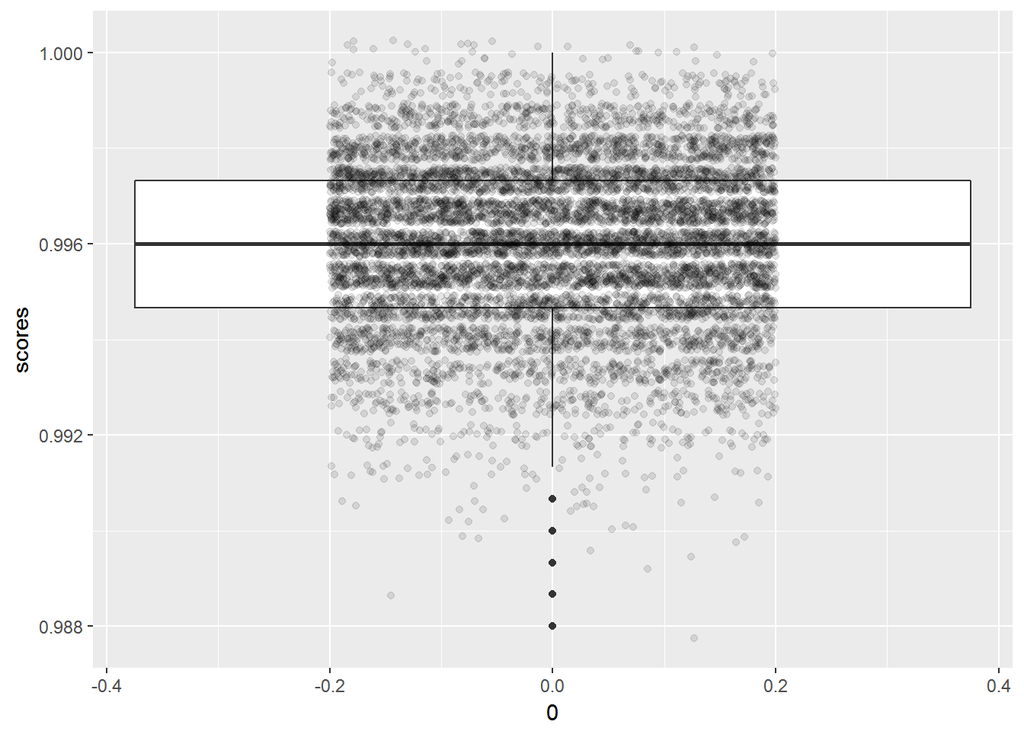

```r
dados %>%
  ggplot(aes(x = 0, y = scores)) +
  geom_boxplot() +
  geom_point(position = position_jitter(width = .2), alpha=0.1)
```

Agora, vamos analisar a distribuição dos scores:

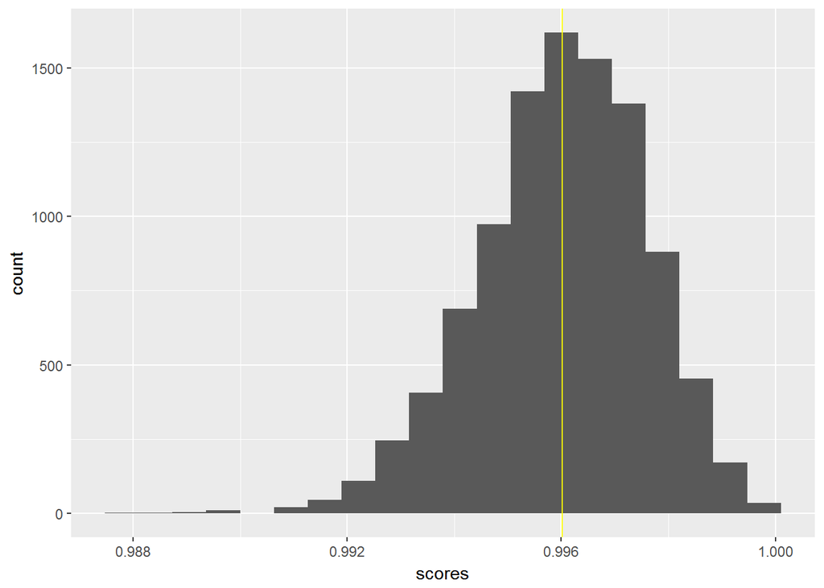

```r
dados %>%
  ggplot(aes(x=scores)) +
  geom_histogram(bins = 20) +
  geom_vline(xintercept = mean(dados$scores), color = "yellow")
```

Por fim, vamos calcular o intervalo de confiança utilizando o método bootstrap:

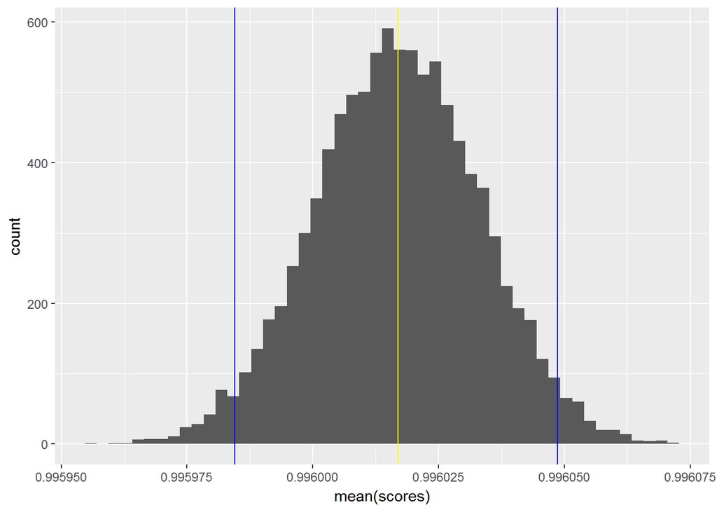

```r
mean.scores <- bootstrap(dados, mean(scores), R=10000, seed = 42)
ci.scores <- mean.scores %>% CI.bca(probs = c(0.025, 0.975))

mean.scores$replicates %>%
  as.data.frame() %>%
  ggplot(aes(x = `mean(scores)`)) +
  geom_histogram(bins=50) +
  geom_vline(xintercept = as.vector(ci.scores)[1], color = "blue") +
  geom_vline(xintercept = as.vector(ci.scores)[2], color = "blue") +
  geom_vline(xintercept = mean(dados$scores), color = "yellow")
```

```r
ci.scores
```

```
##                   2.5%     97.5%
## mean(scores) 0.9959844 0.9960486
```

Pode-se afirmar, então, com 95% de confiança, que a acurácia média da população está entre [0.9959, 0.9960].